# Numpy 简介

## 导入numpy

**Numpy**是**Python**的一个很重要的第三方库，很多其他科学计算的第三方库都是以**Numpy**为基础建立的。

**Numpy**的一个重要特性是它的数组计算。

在使用**Numpy**之前，我们需要导入`numpy`包：

```python
from numpy import *
```

使用前一定要先导入 Numpy 包，导入的方法有以下几种：

```
import numpy
    import numpy as np
    from numpy import *
    from numpy import array, sin
```

事实上，在**ipython**中可以使用magic命令来快速导入**Numpy**的内容。

```python
%pylab
```

```
Using matplotlib backend: Qt4Agg
```

## 数组上的数学操作

假如我们想将列表中的每个元素增加`1`，但列表不支持这样的操作（报错）：

```python
a = [1, 2, 3, 4]
a + 1
```

```
---------------------------------------------------------------------------
TypeError                                 Traceback (most recent call last)
<ipython-input-3-068856d2a224> in <module>()
      1 a = [1, 2, 3, 4]
----> 2 a + 1

TypeError: can only concatenate list (not "int") to list
```

转成 `array` ：

```python
a = array(a)
a
```

```
array([1, 2, 3, 4])
```

`array` 数组支持每个元素加 `1` 这样的操作：

```python
a + 1
```

```
array([2, 3, 4, 5])
```

与另一个 `array` 相加，得到对应元素相加的结果：

```python
b = array([2, 3, 4, 5])
a + b
```

```
array([3, 5, 7, 9])
```

对应元素相乘：

```python
a * b
```

```
array([ 2,  6, 12, 20])
```

对应元素乘方：

```python
a ** b
```

```
array([   1,    8,   81, 1024])
```

## 提取数组中的元素

提取第一个元素：

```python
a[0]
```

```
1
```

提取前两个元素：

```python
a[:2]
```

```
array([1, 2])
```

最后两个元素：

```python
a[-2:]
```

```
array([3, 4])
```

将它们相加：

```python
a[:2] + a[-2:]
```

```
array([4, 6])
```

查看 `array` 的形状：

```python
a.shape
```

```
(4L,)
```

修改 `array` 的形状：

```python
a.shape = 2,2
a
```

```
array([[1, 2],
       [3, 4]])
```

## 多维数组

`a` 现在变成了一个二维的数组，可以进行加法：

```python
a + a
```

```
array([[2, 4],
       [6, 8]])
```

乘法仍然是对应元素的乘积，并不是按照矩阵乘法来计算：

```python
a * a
```

```
array([[ 1,  4],
       [ 9, 16]])
```

## 画图

linspace 用来生成一组等间隔的数据：

```python
a = linspace(0, 2*pi, 21)
%precision 3
a
```

```
array([ 0.   ,  0.314,  0.628,  0.942,  1.257,  1.571,  1.885,  2.199,
        2.513,  2.827,  3.142,  3.456,  3.77 ,  4.084,  4.398,  4.712,
        5.027,  5.341,  5.655,  5.969,  6.283])
```

三角函数：

```python
b = sin(a)
b
```

```
array([  0.000e+00,   3.090e-01,   5.878e-01,   8.090e-01,   9.511e-01,
         1.000e+00,   9.511e-01,   8.090e-01,   5.878e-01,   3.090e-01,
         1.225e-16,  -3.090e-01,  -5.878e-01,  -8.090e-01,  -9.511e-01,
        -1.000e+00,  -9.511e-01,  -8.090e-01,  -5.878e-01,  -3.090e-01,
        -2.449e-16])
```

画出图像：

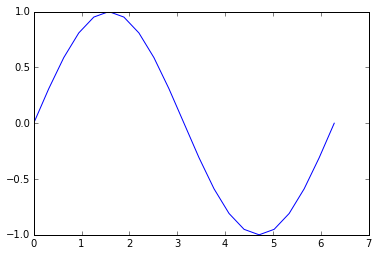

```python
%matplotlib inline
plot(a, b)
```

## 从数组中选择元素

假设我们想选取数组b中所有非负的部分，首先可以利用 `b` 产生一组布尔值：

```python
b >= 0
```

```
array([ True,  True,  True,  True,  True,  True,  True,  True,  True,
        True,  True, False, False, False, False, False, False, False,
       False, False, False], dtype=bool)
```

```python
mask = b >= 0
```

画出所有对应的非负值对应的点：

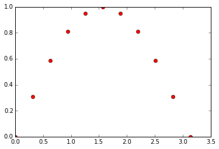

```python
plot(a[mask], b[mask], 'ro')
```